# Credit Card Fraud Prediction

2024W Doing Data Science - Semester Project

Authors

Elizaveta Kotikova

Martyna Janina Kopyta

Péter Ferenc Gyarmati

Published

November 27, 2024

# Project Understanding

## What Is the Problem and Expected Benefit?

The problem at hand is credit card fraud prediction. The goal is to develop a model that can accurately identify fraudulent transactions from legitimate ones based on the given dataset. The expected benefits of this project include:

1. Reduced financial losses for credit card companies and cardholders
2. Improved customer trust and satisfaction
3. Enhanced security measures for credit card transactions
4. More efficient allocation of resources for fraud investigation

## How Would a Solution Look like?

A potential solution would be building and training a machine learning model to **classify transactions as fraudulent or legitimate**, then assessing the model’s performance using metrics such as accuracy, precision, recall, and F1-score, with a **focus on minimizing false negatives (missed fraudulent transactions)**. This would be followed by implementing the model in a production environment where it can process transactions in real-time and flag potentially fraudulent activities. As part of the solution we would need to continuously monitor the model’s performance and retraining it periodically to **adapt to new fraud patterns**.

## What Is Known about the Domain?

### Anomalous Patterns

Fraudulent transactions often exhibit atypical patterns, such as sudden large transactions, high-frequency purchases in a short time, or transactions from unusual locations.

### Data Imbalance

Fraudulent transactions are relatively rare compared to legitimate ones, leading to class imbalance, which must be addressed during model training to avoid bias towards the majority class.

### Feature Importance

Features such as transaction amount, location, time, and merchant details can be critical in identifying fraud. Combining these features with historical customer behavior data can improve model accuracy.

### Regulatory Requirements

Solutions must comply with data privacy regulations like GDPR, which mandate how personal data is handled and processed.

### Continuous Evolution

Fraudsters constantly change their tactics, necessitating the continuous adaptation and updating of fraud detection systems to keep up with new patterns.

### Costly false positives

False positives (legitimate transactions flagged as fraud) can lead to customer inconvenience, while false negatives (missed fraudulent transactions) can result in financial losses, making the balance between precision and recall crucial.

# Data Understanding

## What Data Do We Have Available?

The [Credit Card Fraud Prediction dataset](https://www.kaggle.com/datasets/kelvinkelue/credit-card-fraud-prediction) offers a variety of attributes valuable for comprehensive analysis. It contains 555,719 instances and 22 attributes, a mix of categorical and numerical data types. Importantly, the dataset is complete with no null values. Below is a breakdown of the attributes.

| Field | Description |
| --- | --- |
| `trans_date_trans_time` | Transaction date and time |
| `cc_num` | Unique customer identification number |
| `merchant` | The merchant involved in the transaction |
| `category` | Transaction type (e.g., personal, childcare) |
| `amt` | Transaction amount |
| `first` | Cardholder’s first name |
| `last` | Cardholder’s last name |
| `gender` | Cardholder’s gender |
| `street` | Cardholder’s street address |
| `city` | Cardholder’s city of residence |
| `state` | Cardholder’s state of residence |
| `zip` | Cardholder’s zip code |
| `lat` | Latitude of cardholder’s location |
| `long` | Longitude of cardholder’s location |
| `city_pop` | Population of the cardholder’s city |
| `job` | Cardholder’s job title |
| `dob` | Cardholder’s date of birth |
| `trans_num` | Unique transaction identifier |
| `unix_time` | Transaction timestamp (Unix format) |
| `merch_lat` | Merchant’s location (latitude) |
| `merch_long` | Merchant’s location (longitude) |
| `is_fraud` | Fraudulent transaction indicator (1 = fraud, 0 = legitimate). This is the target variable for classification purposes |

shape: (555_719, 23)

| i64 | trans_date_trans_time str | cc_num f64 | merchant str | category str | amt f64 | first str | last str | gender str | street str | city str | state str | zip i64 | lat f64 | long f64 | city_pop i64 | job str | dob str | trans_num str | unix_time i64 | merch_lat f64 | merch_long f64 | is_fraud i64 |
| --- | --- | --- | --- | --- | --- | --- | --- | --- | --- | --- | --- | --- | --- | --- | --- | --- | --- | --- | --- | --- | --- | --- |
| 0 | "21/06/2020 12:14" | 2.2912e15 | "fraud_Kirlin and Sons" | "personal_care" | 2.86 | "Jeff" | "Elliott" | "M" | "351 Darlene Green" | "Columbia" | "SC" | 29209 | 33.9659 | -80.9355 | 333497 | "Mechanical engineer" | "19/03/1968" | "2da90c7d74bd46a0caf3777415b3eb… | 1371816865 | 33.986391 | -81.200714 | 0 |
| 1 | "21/06/2020 12:14" | 3.5730e15 | "fraud_Sporer-Keebler" | "personal_care" | 29.84 | "Joanne" | "Williams" | "F" | "3638 Marsh Union" | "Altonah" | "UT" | 84002 | 40.3207 | -110.436 | 302 | "Sales professional, IT" | "17/01/1990" | "324cc204407e99f51b0d6ca0055005… | 1371816873 | 39.450498 | -109.960431 | 0 |
| 2 | "21/06/2020 12:14" | 3.5982e15 | "fraud_Swaniawski, Nitzsche and… | "health_fitness" | 41.28 | "Ashley" | "Lopez" | "F" | "9333 Valentine Point" | "Bellmore" | "NY" | 11710 | 40.6729 | -73.5365 | 34496 | "Librarian, public" | "21/10/1970" | "c81755dbbbea9d5c77f094348a7579… | 1371816893 | 40.49581 | -74.196111 | 0 |
| 3 | "21/06/2020 12:15" | 3.5919e15 | "fraud_Haley Group" | "misc_pos" | 60.05 | "Brian" | "Williams" | "M" | "32941 Krystal Mill Apt. 552" | "Titusville" | "FL" | 32780 | 28.5697 | -80.8191 | 54767 | "Set designer" | "25/07/1987" | "2159175b9efe66dc301f149d3d5abf… | 1371816915 | 28.812398 | -80.883061 | 0 |
| 4 | "21/06/2020 12:15" | 3.5268e15 | "fraud_Johnston-Casper" | "travel" | 3.19 | "Nathan" | "Massey" | "M" | "5783 Evan Roads Apt. 465" | "Falmouth" | "MI" | 49632 | 44.2529 | -85.017 | 1126 | "Furniture designer" | "06/07/1955" | "57ff021bd3f328f8738bb535c302a3… | 1371816917 | 44.959148 | -85.884734 | 0 |
| … | … | … | … | … | … | … | … | … | … | … | … | … | … | … | … | … | … | … | … | … | … | … |
| 555714 | "31/12/2020 23:59" | 3.0561e13 | "fraud_Reilly and Sons" | "health_fitness" | 43.77 | "Michael" | "Olson" | "M" | "558 Michael Estates" | "Luray" | "MO" | 63453 | 40.4931 | -91.8912 | 519 | "Town planner" | "13/02/1966" | "9b1f753c79894c9f4b71f04581835a… | 1388534347 | 39.946837 | -91.333331 | 0 |
| 555715 | "31/12/2020 23:59" | 3.5566e15 | "fraud_Hoppe-Parisian" | "kids_pets" | 111.84 | "Jose" | "Vasquez" | "M" | "572 Davis Mountains" | "Lake Jackson" | "TX" | 77566 | 29.0393 | -95.4401 | 28739 | "Futures trader" | "27/12/1999" | "2090647dac2c89a1d86c514c427f5b… | 1388534349 | 29.661049 | -96.186633 | 0 |
| 555716 | "31/12/2020 23:59" | 6.0117e15 | "fraud_Rau-Robel" | "kids_pets" | 86.88 | "Ann" | "Lawson" | "F" | "144 Evans Islands Apt. 683" | "Burbank" | "WA" | 99323 | 46.1966 | -118.9017 | 3684 | "Musician" | "29/11/1981" | "6c5b7c8add471975aa0fec023b2e84… | 1388534355 | 46.65834 | -119.715054 | 0 |
| 555717 | "31/12/2020 23:59" | 4.0798e12 | "fraud_Breitenberg LLC" | "travel" | 7.99 | "Eric" | "Preston" | "M" | "7020 Doyle Stream Apt. 951" | "Mesa" | "ID" | 83643 | 44.6255 | -116.4493 | 129 | "Cartographer" | "15/12/1965" | "14392d723bb7737606b2700ac791b7… | 1388534364 | 44.470525 | -117.080888 | 0 |
| 555718 | "31/12/2020 23:59" | 4.1707e15 | "fraud_Dare-Marvin" | "entertainment" | 38.13 | "Samuel" | "Frey" | "M" | "830 Myers Plaza Apt. 384" | "Edmond" | "OK" | 73034 | 35.6665 | -97.4798 | 116001 | "Media buyer" | "10/05/1993" | "1765bb45b3aa3224b4cdcb6e7a96ce… | 1388534374 | 36.210097 | -97.036372 | 0 |

## Is the Data Relevant to the Problem?

The data is highly relevant to the problem of credit card fraud prediction. The dataset contains numerous attributes that can help in distinguishing between fraudulent and legitimate transactions.

### Comprehensive Attributes

The dataset includes both categorical and numerical features that are important for fraud detection, such as transaction amount, merchant details, and location information (both cardholder and merchant). These can help identify patterns that are typical of fraudulent transactions.

### Fraud Indicator

The presence of the `is_fraud` attribute, which indicates whether a transaction is fraudulent or legitimate, makes it possible to use the dataset for supervised learning tasks aimed at building classification models.

### Demographic and Behavioral Data

Information about the cardholder, such as name, address, city population, job, and transaction history, can provide insights into normal behavior patterns, aiding in the detection of anomalies that may indicate fraud.

### Temporal Data

The inclusion of timestamps allows for the analysis of transaction sequences and timings, which are essential for identifying suspicious activity patterns, such as high-frequency transactions in a short period.

### Location Data

The latitude and longitude data for both the cardholder and the merchant can help detect unusual location-based patterns, like transactions occurring far from the cardholder’s usual locations.

## Data Metrics

The dataset looks valid, reflecting our expectations about transactions. The data is complete, with no missing values, and the attributes are well-distributed across the dataset. The target variable `is_fraud` is binary, with a class imbalance favoring legitimate transactions, which is typical in fraud detection datasets. The quantity of data looks sufficient for training a machine learning model.

Our only concern is about the recency of the data, as it only covers the year 2020, and fraud patterns may have evolved since then. Therefore, there is a risk that the model trained on this data may not generalize well to current fraud patterns.

# Research Questions

| # | Question | Data Science Task | Principle |
| --- | --- | --- | --- |
| 1 | What are the temporal patterns associated with fraudulent transactions (e.g., time of day, day of the week)? | Time Series Analysis | Explore temporal trends and seasonality to identify patterns in fraudulent transactions. |
| 2 | How do transaction locations correlate with the likelihood of fraud, and can geographic patterns be detected? | Geospatial Analysis | Use geospatial visualization and analysis to detect anomalies based on transaction locations. |
| 3 | Can we cluster transactions based on features to identify distinct groups, and are certain clusters more prone to fraud? | Clustering | Apply clustering algorithms like K-means to find natural groupings of transactions and investigate fraud prevalence in each cluster. |
| 4 | What is the impact of demographic factors (e.g., age, job title) on fraud risk? | Exploratory Data Analysis (EDA) and Feature Engineering | Perform EDA to explore relationships between demographic features and fraud, and create new features that capture these insights. |
| 5 | What are the most effective strategies for minimizing false positives without significantly increasing false negatives? | Precision-Recall Analysis and Threshold Tuning | Analyze precision-recall trade-offs and adjust decision thresholds to optimize the balance between false positives and negatives. |

# Data Exploration

We set off by converting dates stored as strings to datetime objects and casting `is_fraud` to a boolean type. We also enrich the dataset with further features to facilitate downstream analysis. We add:

- `state_name`: Full state names based on the 2-letter state codes
- `age`: Cardholder’s age calculated from the date of birth
- `day_of_week`: Day of the week extracted from the transaction timestamp
- `hour_of_day`: Hour of the day extracted from the transaction timestamp

shape: (555_719, 18)

| trans_date_trans_time datetime[μs] | hour_of_day i8 | day_of_week i8 | category str | gender str | state str | state_name str | city str | lat f64 | long f64 | city_pop i64 | job str | dob datetime[μs] | age i8 | merchant str | merch_lat f64 | merch_long f64 | is_fraud bool |
| --- | --- | --- | --- | --- | --- | --- | --- | --- | --- | --- | --- | --- | --- | --- | --- | --- | --- |
| 2020-06-21 12:14:00 | 12 | 7 | "personal_care" | "M" | "SC" | "South Carolina" | "Columbia" | 33.9659 | -80.9355 | 333497 | "Mechanical engineer" | 1968-03-19 00:00:00 | 56 | "Kirlin and Sons" | 33.986391 | -81.200714 | false |
| 2020-06-21 12:14:00 | 12 | 7 | "personal_care" | "F" | "UT" | "Utah" | "Altonah" | 40.3207 | -110.436 | 302 | "Sales professional, IT" | 1990-01-17 00:00:00 | 34 | "Sporer-Keebler" | 39.450498 | -109.960431 | false |
| 2020-06-21 12:14:00 | 12 | 7 | "health_fitness" | "F" | "NY" | "New York" | "Bellmore" | 40.6729 | -73.5365 | 34496 | "Librarian, public" | 1970-10-21 00:00:00 | 54 | "Swaniawski, Nitzsche and Welch" | 40.49581 | -74.196111 | false |
| 2020-06-21 12:15:00 | 12 | 7 | "misc_pos" | "M" | "FL" | "Florida" | "Titusville" | 28.5697 | -80.8191 | 54767 | "Set designer" | 1987-07-25 00:00:00 | 37 | "Haley Group" | 28.812398 | -80.883061 | false |
| 2020-06-21 12:15:00 | 12 | 7 | "travel" | "M" | "MI" | "Michigan" | "Falmouth" | 44.2529 | -85.017 | 1126 | "Furniture designer" | 1955-07-06 00:00:00 | 69 | "Johnston-Casper" | 44.959148 | -85.884734 | false |
| … | … | … | … | … | … | … | … | … | … | … | … | … | … | … | … | … | … |
| 2020-12-31 23:59:00 | 23 | 4 | "health_fitness" | "M" | "MO" | "Missouri" | "Luray" | 40.4931 | -91.8912 | 519 | "Town planner" | 1966-02-13 00:00:00 | 58 | "Reilly and Sons" | 39.946837 | -91.333331 | false |
| 2020-12-31 23:59:00 | 23 | 4 | "kids_pets" | "M" | "TX" | "Texas" | "Lake Jackson" | 29.0393 | -95.4401 | 28739 | "Futures trader" | 1999-12-27 00:00:00 | 25 | "Hoppe-Parisian" | 29.661049 | -96.186633 | false |
| 2020-12-31 23:59:00 | 23 | 4 | "kids_pets" | "F" | "WA" | "Washington" | "Burbank" | 46.1966 | -118.9017 | 3684 | "Musician" | 1981-11-29 00:00:00 | 43 | "Rau-Robel" | 46.65834 | -119.715054 | false |
| 2020-12-31 23:59:00 | 23 | 4 | "travel" | "M" | "ID" | "Idaho" | "Mesa" | 44.6255 | -116.4493 | 129 | "Cartographer" | 1965-12-15 00:00:00 | 59 | "Breitenberg LLC" | 44.470525 | -117.080888 | false |
| 2020-12-31 23:59:00 | 23 | 4 | "entertainment" | "M" | "OK" | "Oklahoma" | "Edmond" | 35.6665 | -97.4798 | 116001 | "Media buyer" | 1993-05-10 00:00:00 | 31 | "Dare-Marvin" | 36.210097 | -97.036372 | false |

## Temporal Patterns

### Fraudulent Transactions by Hour of the Day

It is evident that fraudulent transactions are more likely to occur during the night hours, particularly between 22:00 and 03:00. This pattern could be due to reduced monitoring and increased vulnerability during these hours.

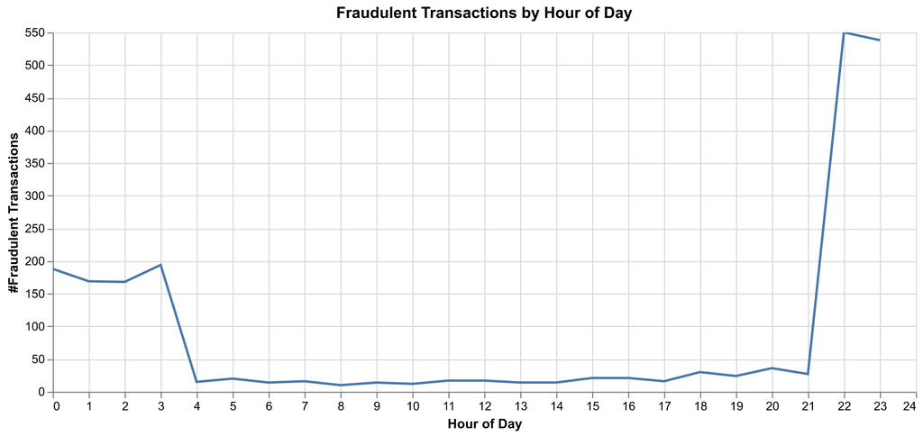

### Fraudulent Transactions by Day of the Week

The distribution of fraudulent transactions across the days of the week is relatively uniform, with a slight increase on Sundays. This could be attributed to higher transaction volumes on weekends, providing more opportunities for fraudulent activities.

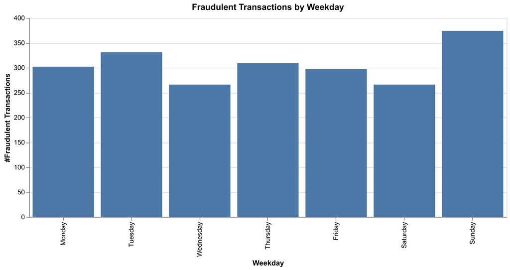

## Geographic Patterns

### Fraudulent Transactions by State

The top states with the highest number of fraudulent transactions are New York, Pennsylvania, and Texas. This could be due to higher population densities and increased transaction volumes in these states, making it easier for fraudsters to blend in.

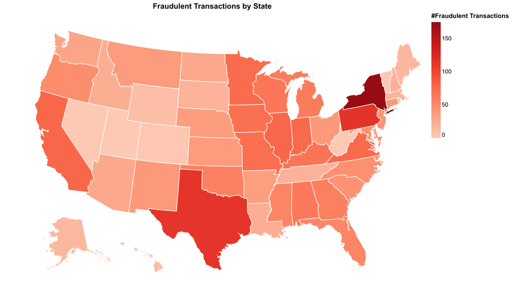